# Inferential Statistics

Dr. Qiusheng Wu

## Generating random samples

Suppose that we interview 500 students on campus, and the results show that the average student spends about 100 minutes each day preparing for classes with a standard deviation of 10 minutes.

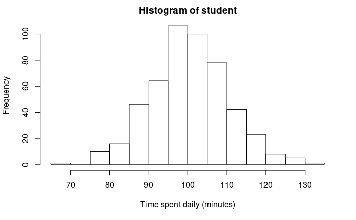

```r
n <- 500
time.mean <- 100
time.sd <- 10
student <- rnorm(n,mean = time.mean,sd=time.sd)
hist(student,breaks = 10,xlab="Time spent daily (minutes)")
```

```r
print(mean(student))
```

```
[1] 100.4565
```

```r
print(sd(student))
```

```
[1] 9.829197
```

## Sampling distribution of the mean

What if we repeat the interview many times, e.g., 300 times?

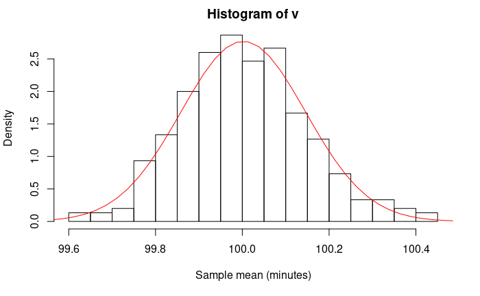

```r
n <- 5000
m <- 300
time.mean <- 100
time.sd <- 10
v <- vector()
for (i in 1:m) {
  x <- rnorm(n,time.mean,time.sd)
  avg <- mean(x)
  std <- sd(x)
  v <- c(v,avg)
  # print(avg)
  # print(std/sqrt(n))
}
hist(v,breaks = 15,freq = FALSE,xlab = "Sample mean (minutes)")
curve(dnorm(x,mean(v),sd(v)),from = 95,to = 105,add = TRUE,n = 400,col = "red")
```

```r
mean(v)
```

```
[1] 100.0021
```

```r
sd(v)
```

```
[1] 0.1438992
```

## Confidence interval for the mean

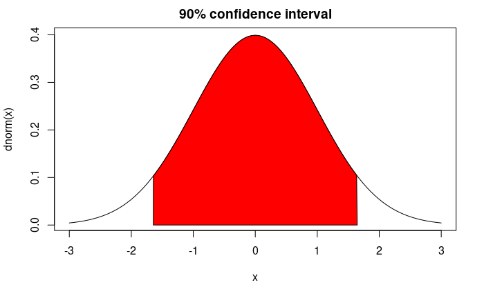

```r
q90 <- qnorm(0.95)  # 90% confidence interval
curve(dnorm,from = -3,to = 3,main = "90% confidence interval")
x <- c(-q90,seq(-q90,q90,by = 0.01),q90)
y <- c(0,dnorm(seq(-q90,q90,by = 0.01)),0)
polygon(x,y,col = "red")
```

qnorm(0.95) = 1.64

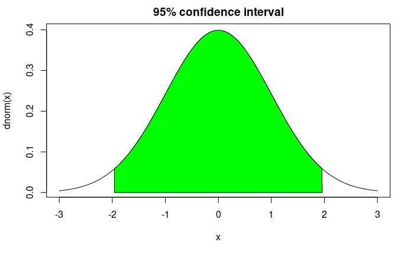

```r
q95 <- qnorm(0.975)  # 95% confidence interval
curve(dnorm,from = -3,to = 3,main="95% confidence interval")
x <- c(-q95,seq(-q95,q95,by = 0.01),q95)
y <- c(0,dnorm(seq(-q95,q95,by = 0.01)),0)
polygon(x,y,col="green")
```

qnorm(0.975) = 1.96

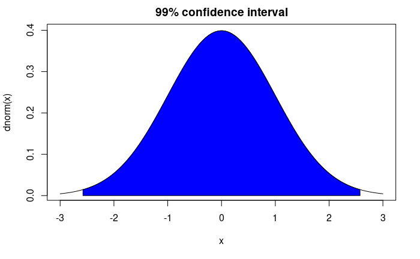

```r
q99 <- qnorm(0.995) # 99% confidence interval
curve(dnorm,from = -3,to = 3,main="99% confidence interval")
x <- c(-q99,seq(-q99,q99,by = 0.01),q99)
y <- c(0,dnorm(seq(-q99,q99,by = 0.01)),0)
polygon(x,y,col="blue")
```

qnorm(0.995) = 2.58

Suppose that we interview 500 students on campus, and the results show that the average student spends about 100 minutes each day preparing for classes with a standard deviation of 10 minutes. Find 90%, 95%, and 99% confidence intervals.

```r
q90 <- qnorm(0.950)  # 90% confidence interval
round(q90,2)
```

```
[1] 1.64
```

```r
q95 <- qnorm(0.975)  # 95% confidence interval
round(q95,2)
```

```
[1] 1.96
```

```r
q99 <- qnorm(0.995)  # 99% confidence interval
round(q99,2)
```

```
[1] 2.58
```

```r
std.err <- 10/sqrt(500)
conf.90 <- c(100-q90*std.err,100+q90*std.err) #[99.26, 100.74]
round(conf.90,2)
```

```
[1]  99.26 100.74
```

```r
conf.95 <- c(100-q95*std.err,100+q95*std.err) #[99.12, 100.88]
round(conf.95,2)
```

```
[1]  99.12 100.88
```

```r
conf.99 <- c(100-q99*std.err,100+q99*std.err) #[98.85, 101.15]
round(conf.99,2)
```

```
[1]  98.85 101.15
```

## Using mvrnorm function

How to generate random samples from the specified normal distribution with the exact mean and standard deviation?

```r
library(MASS)
x <- mvrnorm(n = 500,mu = 100,Sigma = 100,empirical = TRUE)
mean(x)
```

```
[1] 100
```

```r
sd(x)
```

```
[1] 10
```

## Finding Confidence Interval

### Problem

You have a sample from a population. Given that sample, you want to determine a confidence interval for the population’s mean.

### Solution

- Apply the t.test function to your sample `x`:
- `t.test(x)`
- The output includes a confidence interval at the 95% confidence level. To see intervals at other levels, use the conf.level argument.

### Example

```r
library(MASS)
x <- mvrnorm(n = 500,mu = 100,Sigma = 100,empirical = TRUE)
t.test(x,conf.level = 0.90)    #[99.26, 100.74]
```

```
    One Sample t-test

data:  x
t = 223.61, df = 499, p-value < 2.2e-16
alternative hypothesis: true mean is not equal to 0
90 percent confidence interval:
  99.26303 100.73697
sample estimates:
mean of x
      100
```

```r
t.test(x,conf.level = 0.95)    #[99.12, 100.88]
```

```
    One Sample t-test

data:  x
t = 223.61, df = 499, p-value < 2.2e-16
alternative hypothesis: true mean is not equal to 0
95 percent confidence interval:
  99.12135 100.87865
sample estimates:
mean of x
      100
```

```r
t.test(x,conf.level = 0.99)    #[98.84, 101.16]
```

```
    One Sample t-test

data:  x
t = 223.61, df = 499, p-value < 2.2e-16
alternative hypothesis: true mean is not equal to 0
99 percent confidence interval:
  98.84363 101.15637
sample estimates:
mean of x
      100
```

### How to extract confidence interval out of t.test() output?

```r
library(MASS)
x <- mvrnorm(n = 500,mu = 100,Sigma = 100,empirical = TRUE)
result <- t.test(x,conf.level = 0.95)
print(result)
```

```
    One Sample t-test

data:  x
t = 223.61, df = 499, p-value < 2.2e-16
alternative hypothesis: true mean is not equal to 0
95 percent confidence interval:
  99.12135 100.87865
sample estimates:
mean of x
      100
```

```r
conf.int <- result$conf.int
print(conf.int)
```

```
[1]  99.12135 100.87865
attr(,"conf.level")
[1] 0.95
```

```r
conf.level <- attr(result$conf.int, "conf.level")
print(conf.level)
```

```
[1] 0.95
```

## One-sample t-test

### Problem

*Null hypothesis*

$H_o:\mu = 100$

*Alternative hypothesis*

$H_{\alpha}:\mu \neq 100$

### Example

```r
library(MASS)
x <- mvrnorm(n = 500,mu = 99,Sigma = 100,empirical = TRUE)
result <- t.test(x,mu = 100)
result
```

```
    One Sample t-test

data:  x
t = -2.2361, df = 499, p-value = 0.02579
alternative hypothesis: true mean is not equal to 100
95 percent confidence interval:
 98.12135 99.87865
sample estimates:
mean of x
       99
```

```r
if(result$p.value>0.05){
  print("We cannot reject the null hypothesis")
} else {
  print("We reject the null hypothesis")}
```

```
[1] "We reject the null hypothesis"
```

## Two-sample t-test

### Problem

Suppose that we interview **50 students** on campus, and the results show that the average student spends about **99 minutes** each day preparing for classes with a standard deviation of **10 minutes**.

Suppose that we interview another **50 students** on campus, and the results show that the average student spends about **98 minutes** each day preparing for classes with a standard deviation of **5 minutes**.

*Null hypothesis*

$H_o: \mu_1 = \mu_2$

*Alternative hypothesis*

$H_o: \mu_1 \neq \mu_2$

### Example

```r
library(MASS)
x1 <- mvrnorm(n = 50,mu = 99,Sigma = 100,empirical = TRUE)
x2 <- mvrnorm(n = 50,mu = 98,Sigma = 25,empirical = TRUE)
result <- t.test(x1,x2)
result
```

```
    Welch Two Sample t-test

data:  x1 and x2
t = 0.63246, df = 72.059, p-value = 0.5291
alternative hypothesis: true difference in means is not equal to 0
95 percent confidence interval:
 -2.151899  4.151899
sample estimates:
mean of x mean of y
       99        98
```

```r
if(result$p.value>0.05){
  print("We cannot reject the null hypothesis")
} else {
  print("We reject the null hypothesis")}
```

```
[1] "We cannot reject the null hypothesis"
```

## Student’s t distribution

### Solution

- `dt(x, df)`
- `pt(q, df,lower.tail = TRUE)`
- `qt(p, df,lower.tail = TRUE)`
- `rt(n, df)`

### Example

```r
qnorm(0.95)
```

```
[1] 1.644854
```

```r
qnorm(0.975)
```

```
[1] 1.959964
```

```r
qnorm(0.995)
```

```
[1] 2.575829
```

```r
qt(0.95,df = 10)
```

```
[1] 1.812461
```

```r
qt(0.975,df = 10)
```

```
[1] 2.228139
```

```r
qt(0.995,df = 10)
```

```
[1] 3.169273
```

```r
curve(dt(x,df = 1),from = -5,to = 5,ylim = c(0,0.4),col = "red")
curve(dt(x,df = 2),from = -5,to = 5,col = "green",add=TRUE)
```

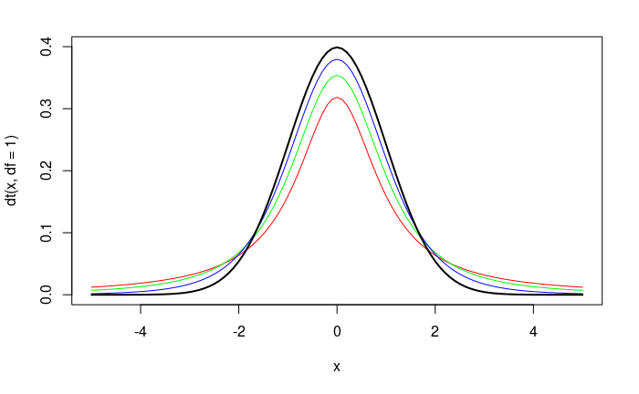

```r
curve(dt(x,df = 5),from = -5,to = 5,col = "blue",add = TRUE)
curve(dnorm,add=TRUE,col ="black",lwd=2)
```

## Testing a sample proportion

### Problem

We want to test the hypothesis that more than 30% of U.S. households have internet access (with a significance level of 5%). We collect a sample of 150 households and find that 57 have access.

### Solution

```r
result <- prop.test(57,n = 150,p = 0.3,alternative = "greater")
result
```

```
    1-sample proportions test with continuity correction

data:  57 out of 150, null probability 0.3
X-squared = 4.1984, df = 1, p-value = 0.02023
alternative hypothesis: true p is greater than 0.3
95 percent confidence interval:
 0.3143179 1.0000000
sample estimates:
   p
0.38
```

```r
if(result$p.value>0.05) {
  print("We cannot reject the null hypothesis ")
} else {
  print("We accept the alternative hypothesis")
}
```

```
[1] "We accept the alternative hypothesis"
```

## Two-sample proportion test

### Problem

A random sample of 428 adults from New York City reveals 128 smokers. A random sample of 682 adults from San Francisco reveals 170 smokers. Is the proportion of adult smokers in New York City different from that in San Francisco?

### Solution

```r
result <- prop.test(x=c(128,170), n=c(428,682))
result
```

```
    2-sample test for equality of proportions with continuity correction

data:  c(128, 170) out of c(428, 682)
X-squared = 3.0718, df = 1, p-value = 0.07966
alternative hypothesis: two.sided
95 percent confidence interval:
 -0.006283211  0.105880328
sample estimates:
   prop 1    prop 2
0.2990654 0.2492669
```

```r
if(result$p.value>0.05) {
  print("We cannot reject the null hypothesis ")
} else {
  print("We accept the alternative hypothesis")
}
```

```
[1] "We cannot reject the null hypothesis "
```

## Online equation editor

- https://www.codecogs.com/latex/eqneditor.php
- http://rogercortesi.com/eqn/